# L07 Scales, Axes & Legends

Data Visualization (STAT 302)

Martha Eichlersmith

2020-05-03

```r
library(knitr)
opts_chunk$set(dpi = 300)
```

## Overview

The goal of this lab is to explore ways to manage and manipulate scales, axes, and legends within `ggplot2`.

## Datasets

We’ll be using the `tech_stocks.rda`, `cdc.txt`, and a few toy datasets.

```r
# Load package(s)
library(tidyverse)
library(scales)

# Load datasets
load(file = "data/tech_stocks.rda")

# Read in the cdc dataset
cdc <- read_delim(file = "data/cdc.txt", delim = "|") %>%
  mutate(genhlth = factor(genhlth,
    levels = c("excellent", "very good", "good", "fair", "poor")
  ))

# Set seed
set.seed(8221984)

# Selecting a random subset of size 100
cdc_small <- cdc %>% sample_n(100)

# Generating toy datasets for exercise 2
dat1 <- tibble(theta = c(0, 2 * pi))

dat2 <- tibble(
  theta = seq(0, 2 * pi, length.out = 100),
  obs = rnorm(100, sin(theta), 0.1),
  larger_than = ifelse(abs(obs) < abs(sin(theta)), "1", "0")
)
```

## Exercises

### Exercise 1

The next plot uses the `tech_stocks` dataset.

*Hints:*

- Size of lines in legend is 1.3
- 0.75 and 0.85 will be useful

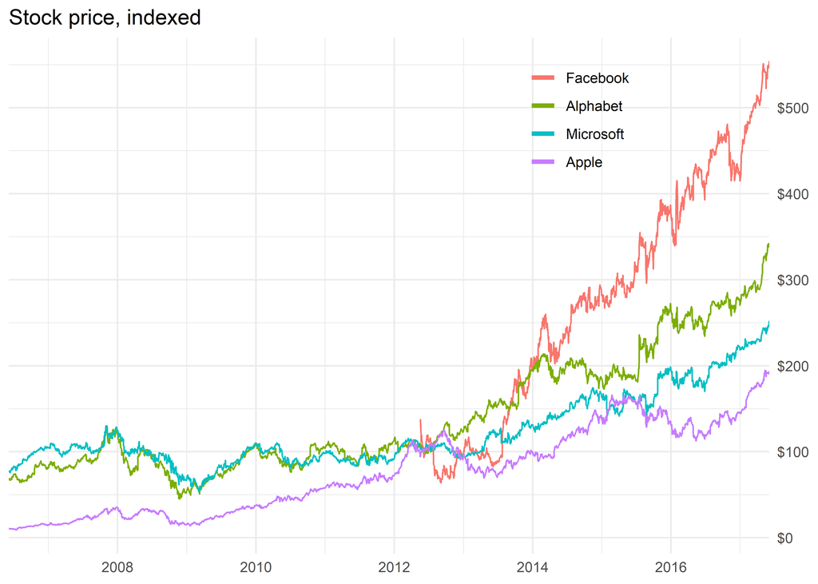

```r
tech_stocks %>%
  ungroup() %>%
ggplot(
      aes(
          date
        , price_indexed
        #reorder based on final values in plot
        , color = fct_reorder2(company, date, price_indexed)
      )
  ) +
  theme_minimal() +
  geom_line() +
  #change line in legends to 1.3
  #use color as that is the what is used in aes() for lines
  guides(color = guide_legend(override.aes = list(size = 1.3))) +
  scale_y_continuous(
      name = NULL
    , breaks = seq(0, 500, 100)
    , labels = scales::dollar
    , position = "right"
  ) +
  scale_color_discrete(
      name = NULL
      #if don't reorder factors; can manually set in limits
#    , limits = c("Facebook", "Alphabet", "Microsoft", "Apple")
  )+
  theme(
      legend.position = c(0.75, 0.85)
  ) +
  scale_x_date(
      name = NULL
    #remove extra padding on plot
    , expand = c(0, 0)
  )+
  ggtitle("Stock price, indexed")
```

### Exercise 2

The next plot uses the toy datasets `dat1` and `dat2`.

*Hints:*

- Sizes used 2 (points) and 1.3 (line)
- Transparency 0.8
- Colors: `#56B4E9`, `darkgreen`, & `red`

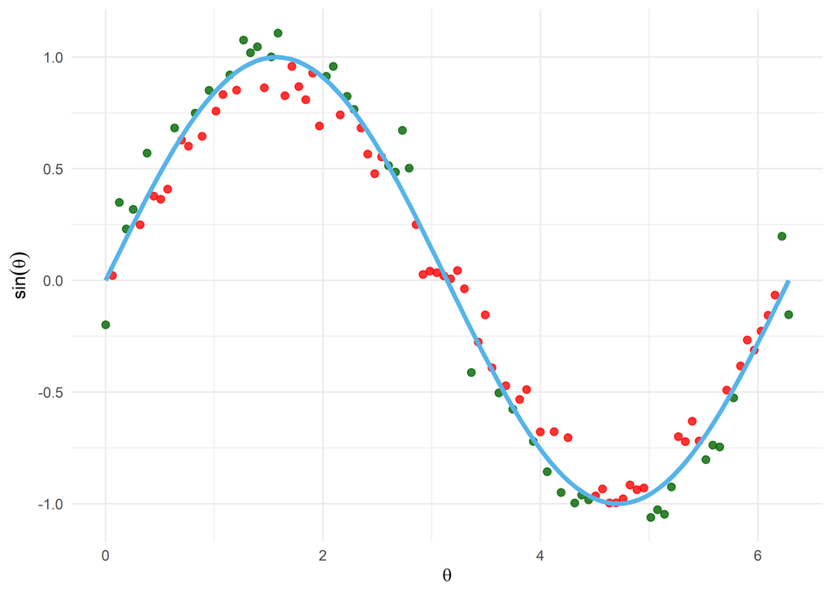

```r
dat2 %>%
  mutate(sin_theta = sin(theta)) %>%
ggplot(aes(theta, obs, color = larger_than)) +
  geom_point(
      size = 2
    , alpha = 0.8
  ) +
  stat_function(
      fun =  sin
    , size = 1.3
    , color = "#56B4E9"
  ) +
  #instead of stat_funnction could use geom_line
  #geom_line(aes(y = sin_theta), size = 1.3, color = "#56B4E9") +
  scale_color_manual(values = c("darkgreen", "red")) +
  xlab( quote(theta) ) +
  ylab( quote(sin(theta)) ) +
  theme_minimal() +
  theme(legend.position = "none")
```

### Exercise 3

Using `cdc_small`construct a scatterplot of `weight` by `height` with the following requirements:

- Size of plotting characters should be 3.
- Color and shape should both identify `genhlth`.
- One legend for both color and shape.
- Legend title should be “General Health?” with a newline starting after general.
- Legend categories should be ordered from excellent (top) to poor (bottom) with each word in category capitalized in the legend.
- Legend should be placed in the lower right-hand corner of the plotting area.
- Color should follow the `"Set1"` pallete.
- Shape should have a solid triangle (17) for excellent, solid circle (19) for very good, an `x` (4) for poor, an hollow rotated square with an `x` in it (9) for fair, and a solid square (15) for good.
- `height` values should be limited between 55 and 80.
- `height` axis should display every 5th number between 55 and 80 and be appropriately labeled (i.e. `55 in`, `60 in`, …, `80 in`). No axis title is necessary.
- `weight` values should be limited between 100 and 300.
- `weight` axis should be on log base 10 scale, but still display weights in pounds starting at 100 and displaying every 25 pounds until 300. Must be appropriately labeled (i.e. `100 lbs`, `125 lbs`, …, `300 lbs`). No axis title is necessary.
- Graph title should be `CDC BRFSS: Weight by Height`.
- Minimal theme.

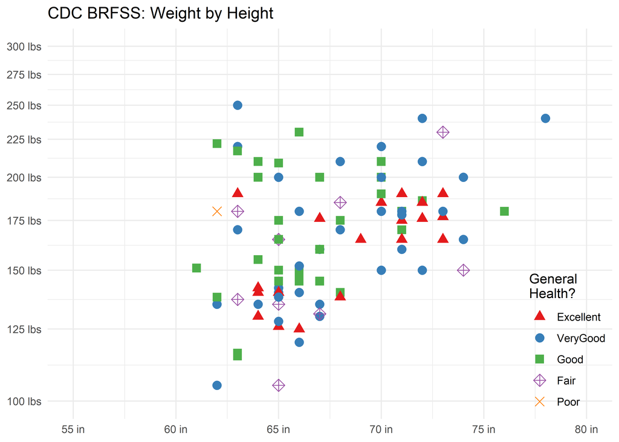

```r
#limits and breaks for HEIGHT
htmin <- 55
htmax <- 80
htdiv <- 5
htnumb <- (htmax-htmin)/htdiv
htbreaks <- seq(htmin, htmax, htdiv)

#limits and breaks for WEIGHT
wtmin <- 100
wtmax <- 300
wtdiv <- 25
wtnumb <- (wtmax-wtmin)/wtdiv
wtbreaks <-seq(wtmin, wtmax, wtdiv)

#Legend title should be "General Health?" with a newline starting after general
leg_title <- "General\nHealth?"

#with each word in category capitalized in the legend
cap_labels <- c("Excellent", "VeryGood", "Good", "Fair", "Poor")

#PLOT
ggplot(cdc_small, aes(height, weight)) +

  geom_point(aes(color = genhlth, shape = genhlth), size = 3) +
  scale_color_brewer(
      name = leg_title
    , labels = cap_labels
    , palette = "Set1"
  ) +
  scale_shape_manual(
      name = leg_title
    , labels = cap_labels
    , values = c(17, 19, 15, 9, 4)
  ) +
  scale_x_continuous(
      name = NULL
    , limits = c(htmin, htmax)
    , breaks = htbreaks
    , labels = scales::unit_format(suffix = " in", accuracy = 1)
  ) +
  scale_y_log10(
      name = NULL
    , limits = c(wtmin, wtmax)
    , breaks = wtbreaks
    , labels = scales::unit_format(unit = "lbs")
  ) +
  theme_minimal() +
  theme(
      legend.position = c(1, 0)
    , legend.justification = c(1, 0)
  ) +
  ggtitle("CDC BRFSS: Weight by Height")
```